# Lung cancer patients

### Information gain:

```r
dataset_ctree <- ctree(myFormula, data = train_data)

## Display the confusion matrix for the training set
table(predict(dataset_ctree), train_data$Level)
```

```
         Low Medium
  Low     73      0
  Medium   0      9
```

```r
## Display the ctree model details
print(dataset_ctree)
```

```
Model formula:
Level ~ Age + Air.Pollution + Alcohol.use + Dust.Allergy + OccuPational.Hazards +
    Genetic.Risk + chronic.Lung.Disease + Balanced.Diet + Obesity +
    Smoking + Passive.Smoker + Chest.Pain + Coughing.of.Blood +
    Fatigue + Weight.Loss + Shortness.of.Breath + Wheezing +
    Swallowing.Difficulty + Clubbing.of.Finger.Nails + Frequent.Cold +
    Dry.Cough + Snoring

Fitted party:
[1] root
|   [2] Genetic.Risk <= 3: Low (n = 73, err = 0.0%)
|   [3] Genetic.Risk > 3: Medium (n = 9, err = 0.0%)

Number of inner nodes:    1
Number of terminal nodes: 2
```

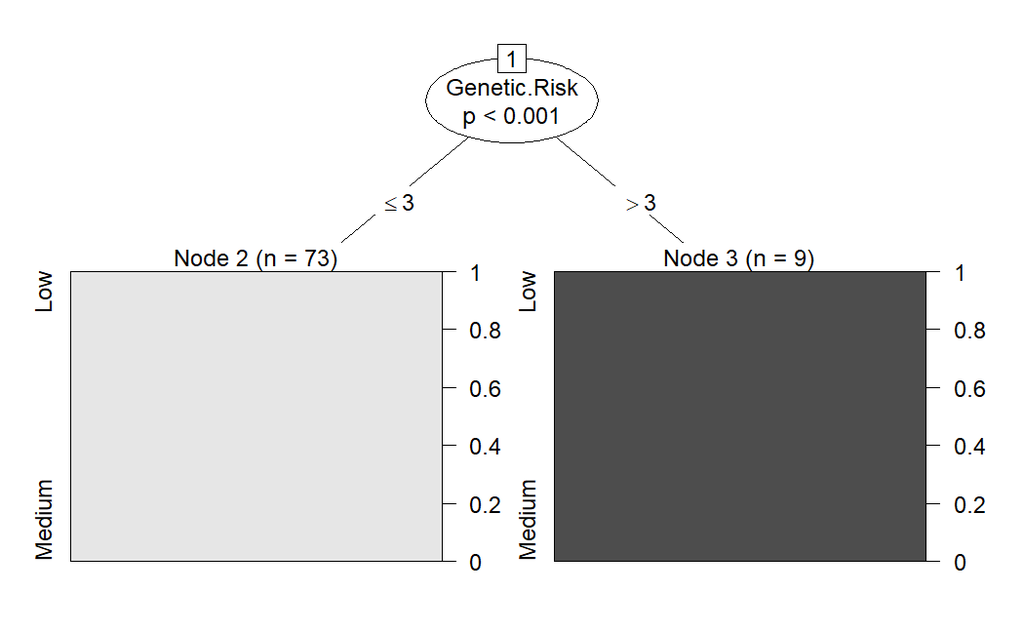

```r
## Plot the ctree model
plot(dataset_ctree)
```

As seen in the graph the split is based on the “Genetic risk” attribute, if the value of “Genetic Risk” is *less than or equal to 3*, the prediction is **“Low”** and there are 73 instances in the group. If the value of “Genetic Risk” is *greater than 3*, the prediction is **“Medium”** and there are 9 instances in the group.

The tree has 1 inner node (root) and 2 terminal nodes (leaves).

```r
## Predict on the testing set using the ctree model
testPred <- predict(dataset_ctree, newdata = test_data)

## Evaluate model performance using confusionMatrix for information gain
results <- confusionMatrix(testPred, test_data$Level, positive = "Low")
print(results)
```

```
Confusion Matrix and Statistics

          Reference
Prediction Low Medium
    Low      8      0
    Medium   0      1

               Accuracy : 1
                 95% CI : (0.6637, 1)
    No Information Rate : 0.8889
    P-Value [Acc > NIR] : 0.3464

                  Kappa : 1

 Mcnemar's Test P-Value : NA

            Sensitivity : 1.0000
            Specificity : 1.0000
         Pos Pred Value : 1.0000
         Neg Pred Value : 1.0000
             Prevalence : 0.8889
         Detection Rate : 0.8889
   Detection Prevalence : 0.8889
      Balanced Accuracy : 1.0000

       'Positive' Class : Low
```

### Gain ratio:

```r
C45Fit <- J48(myFormula, data = train_data)

## Display the confusion matrix for the training set
table(predict(C45Fit), train_data$Level)
```

```
         Low Medium
  Low     73      0
  Medium   0      9
```

```r
## Display the C4.5 decision tree model details
print(C45Fit)
```

```
J48 pruned tree
------------------

Alcohol.use <= 2: Low (73.0)
Alcohol.use > 2: Medium (9.0)

Number of Leaves  :     2

Size of the tree :  3
```

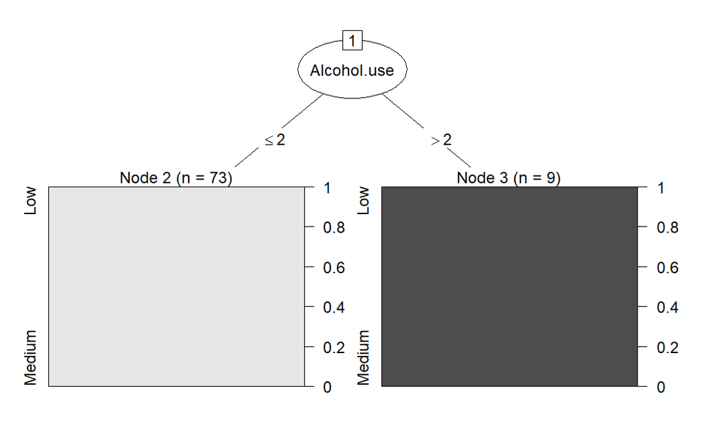

```r
## Plot the C4.5 decision tree model
plot(C45Fit)
```

As seen in the graph the split is based on “Alcohol use” attribute. If the value of “Alcohol use” is *less than or equal to 2*, the prediction is **“Low”** and there are 73 instances in the group. If the value of “Alcohol use” is *greater than 2*, the prediction is **“Medium”** and there are 9 instances in the group.

```r
## Predict on the testing set using the C4.5 decision tree model
testPred <- predict(C45Fit, newdata = test_data)

## Evaluate model performance using confusionMatrix for gain ratio
results <- confusionMatrix(testPred, test_data$Level, positive = "Low")
print(results)
```

```
Confusion Matrix and Statistics

          Reference
Prediction Low Medium
    Low      8      0
    Medium   0      1

               Accuracy : 1
                 95% CI : (0.6637, 1)
    No Information Rate : 0.8889
    P-Value [Acc > NIR] : 0.3464

                  Kappa : 1

 Mcnemar's Test P-Value : NA

            Sensitivity : 1.0000
            Specificity : 1.0000
         Pos Pred Value : 1.0000
         Neg Pred Value : 1.0000
             Prevalence : 0.8889
         Detection Rate : 0.8889
   Detection Prevalence : 0.8889
      Balanced Accuracy : 1.0000

       'Positive' Class : Low
```

### Gini index:

```r
fit.tree <- rpart(myFormula, data = train_data, method = "class", cp = 0.008)

## Display the Gini decision tree model details
print(fit.tree)
```

```
n= 82

node), split, n, loss, yval, (yprob)
      * denotes terminal node

1) root 82 9 Low (0.8902439 0.1097561)
  2) Alcohol.use< 3.5 73 0 Low (1.0000000 0.0000000) *
  3) Alcohol.use>=3.5 9 0 Medium (0.0000000 1.0000000) *
```

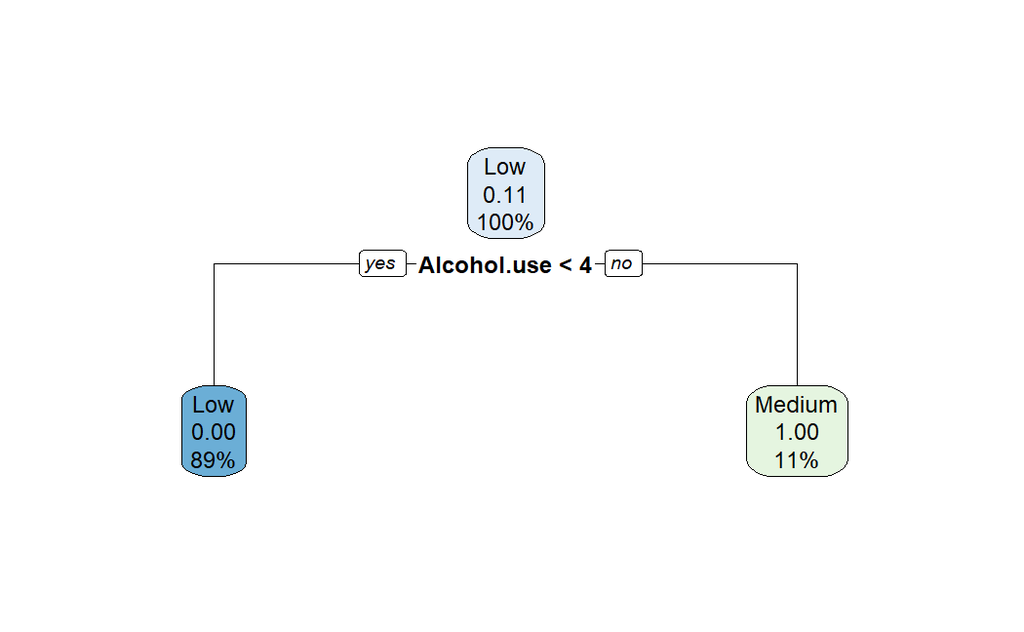

```r
## Plot the Gini decision tree model
rpart.plot(fit.tree)
```

As seen in the graph the split is based on “Alcohol use” attribute, if alcohol use is *less than 4* then go to **“Low”**. If the alcohol use is *greater than 4* then the prediction is **“Medium”.**

```r
## Predict on the testing set using the Gini decision tree model
testPred <- predict(fit.tree, newdata = test_data, type = "class")

## Evaluate model performance using confusionMatrix for Gini index
results <- confusionMatrix(testPred, test_data$Level, positive = "Low")
print(results)
```

```
Confusion Matrix and Statistics

          Reference
Prediction Low Medium
    Low      8      0
    Medium   0      1

               Accuracy : 1
                 95% CI : (0.6637, 1)
    No Information Rate : 0.8889
    P-Value [Acc > NIR] : 0.3464

                  Kappa : 1

 Mcnemar's Test P-Value : NA

            Sensitivity : 1.0000
            Specificity : 1.0000
         Pos Pred Value : 1.0000
         Neg Pred Value : 1.0000
             Prevalence : 0.8889
         Detection Rate : 0.8889
   Detection Prevalence : 0.8889
      Balanced Accuracy : 1.0000

       'Positive' Class : Low
```